# Week 3 Peer Review

Following the directions on the Coursera assignment page, you will make four original visualizations. Note that the data for the CCES and CEL data are imported in code in the R Markdown file.

## Exercise 1

### Scatter plot

Is there correlation between legislative effective score and bills passed? The graphs below show a strong linear association between these 2 variables. Bills passed is likely a strong factor in determining LES. BY splitting by gender, we can see the same association apparent with both genders, with less females passing a large number of bills and scoring highly in LES.

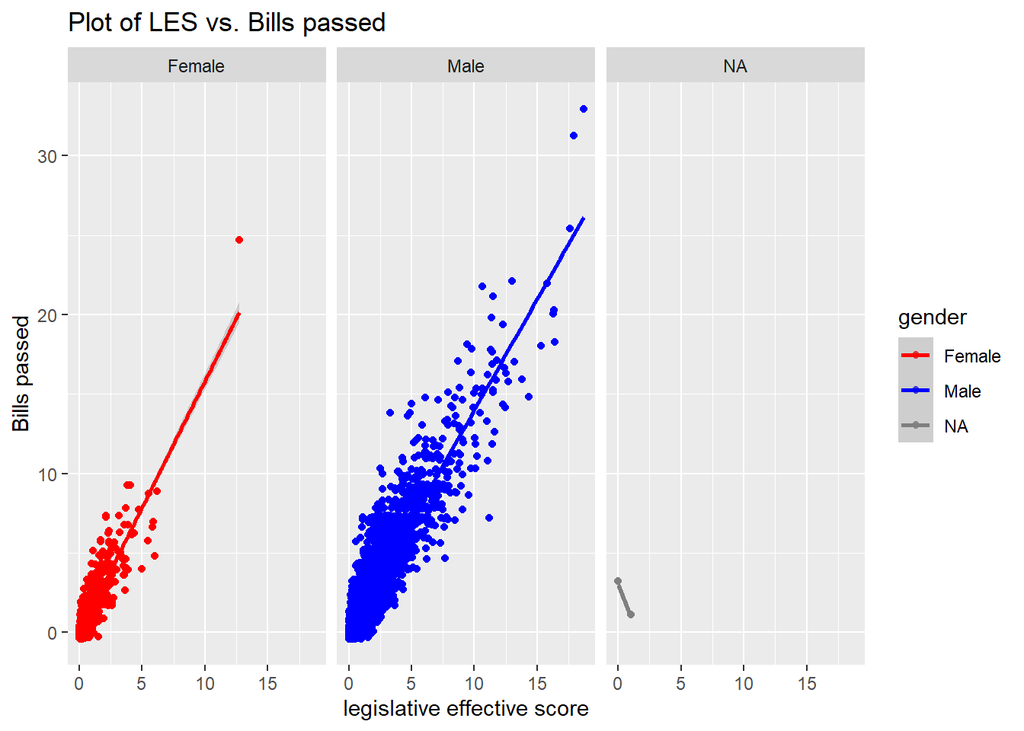

## Exercise 2

### Histogram (distribution plot)

How many MCs are in the member’s state delegation? The below histogram shows a distribution of delegation size. We see right skew with most delegations having fewer numbers of MCs, with a small peak in the largest membership bin.

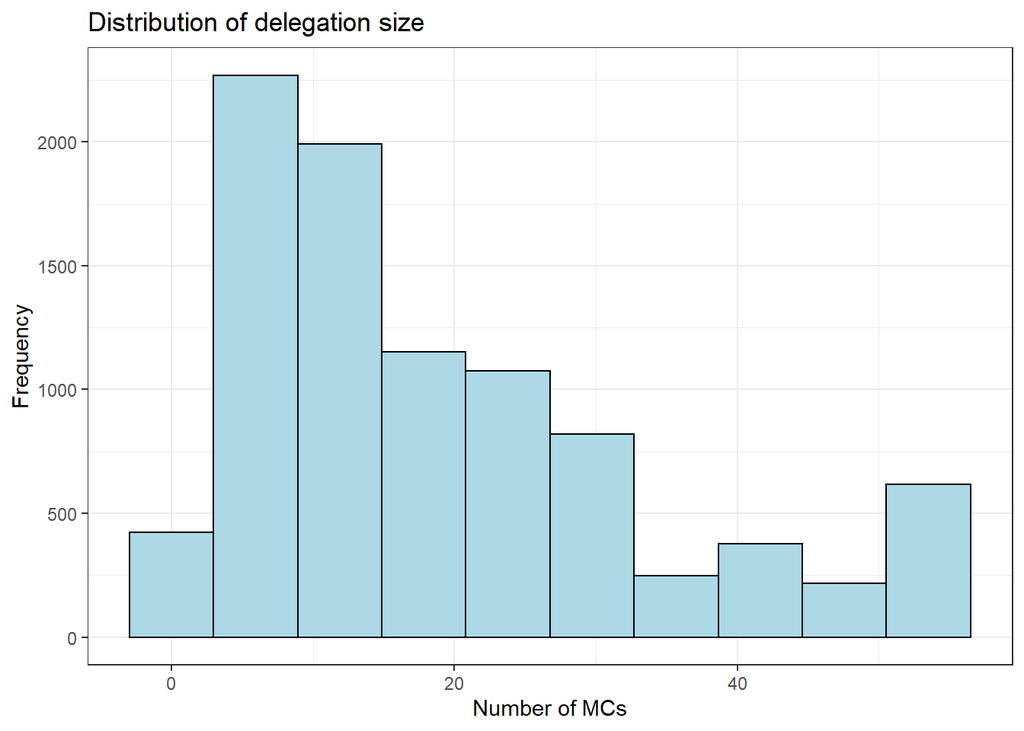

## Exercise 3

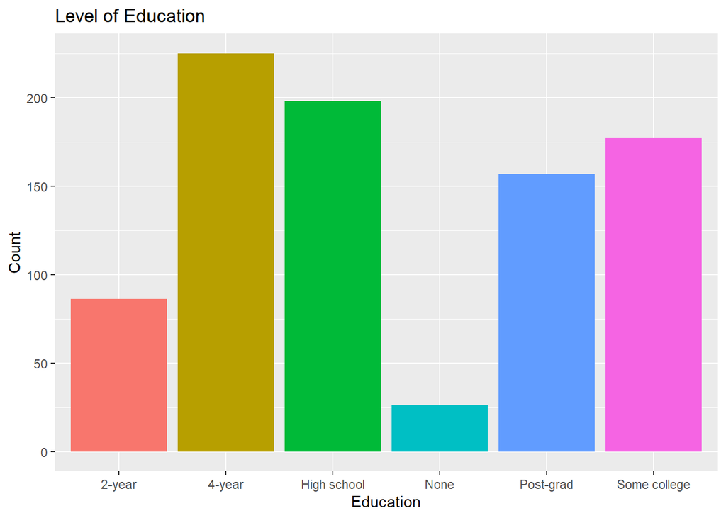

## Exercise 4

Which month recorded the highest and lowest temperatures in the dataset? The line graph indicates that the lowest month was February and the highest month was August.

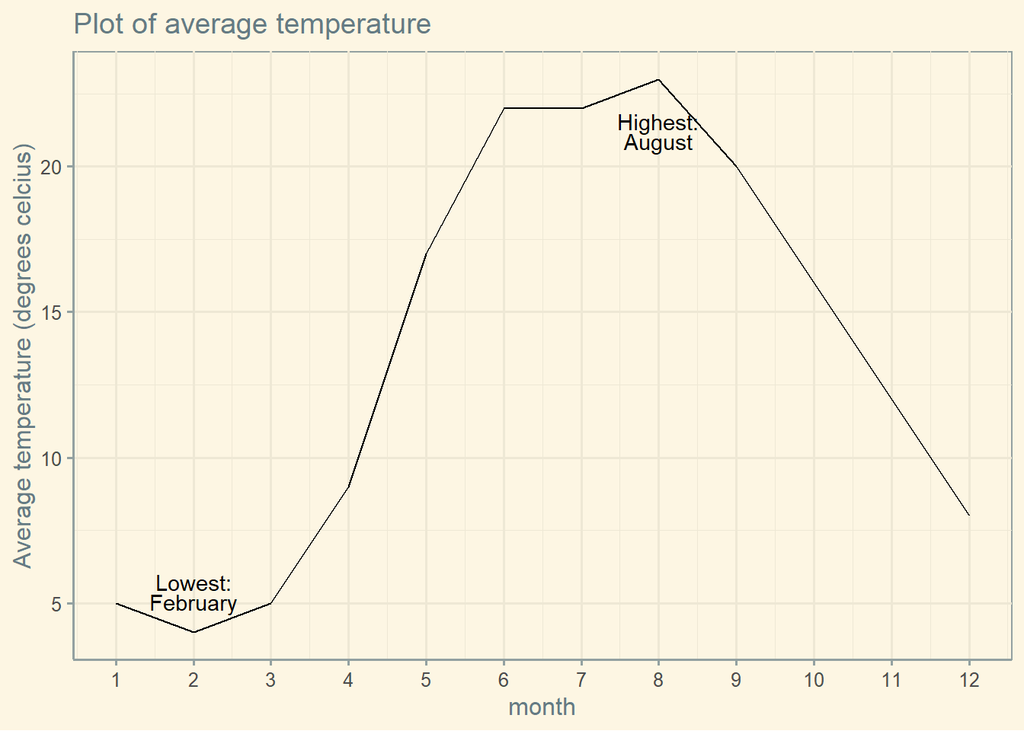